# Reproducible Research : Peer Assessment 1

Roberta Justo

Sunday, September 20, 2015

# Loading and preprocessing the data

```r
echo=TRUE
```

```r
data<- read.csv("activity.csv")
head(data)
```

```
##   steps       date interval
## 1    NA 2012-10-01        0
## 2    NA 2012-10-01        5
## 3    NA 2012-10-01       10
## 4    NA 2012-10-01       15
## 5    NA 2012-10-01       20
## 6    NA 2012-10-01       25
```

# What is mean total number of steps taken per day?

1. Calculate the total number of steps taken per day

```r
library("dplyr")
```

```r
library(ggplot2)

steps_per_day <- summarise(group_by(data,date), steps = sum(steps))
```

2. Make a histogram of the total number of steps taken each day

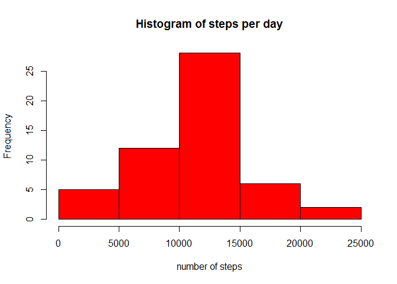

```r
hist(steps_per_day$steps,
     col = "red1",
     main = "Histogram of steps per day",
     xlab = "number of steps")
```

3. Calculate and report the mean and median of the total number of steps taken per day

Mean

```r
mean_steps<- mean(steps_per_day$steps, na.rm=TRUE)
mean_steps
```

```
## [1] 10766.19
```

Median

```r
median_steps<- median(steps_per_day$steps, na.rm=TRUE)
median_steps
```

```
## [1] 10765
```

# What is the average daily activity pattern?

1. Make a time series plot (i.e. type = “l”) of the 5-minute interval (x-axis) and the average number of steps taken, averaged across all days (y-axis)

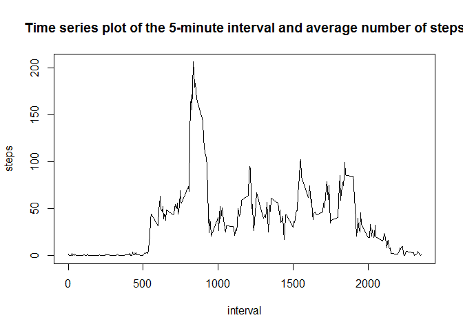

```r
average_per_interval <- summarise(group_by(data,interval), steps = mean(steps, na.rm=TRUE))

plot(average_per_interval$steps ~average_per_interval$interval,
     type="l", xlab = "interval", ylab = "steps", main="Time series plot of the 5-minute interval and average number of steps")
```

2. Which 5-minute interval, on average across all the days in the dataset, contains the maximum number of steps?

```r
average_per_interval[which.max(average_per_interval$steps),]
```

```
## Source: local data frame [1 x 2]
##
##   interval    steps
## 1      835 206.1698
```